# STK4900 - Statistical Methods and Applications

Olivia Beyer Bruvik

6/11/2021

# Lecture 3

## Topics

1. Multiple regression: data structure and basic questions
2. The multiple linear regression model
3. Categorical predictors
4. Planned experiments and observational studies

https://www.uio.no/studier/emner/matnat/math/STK4900/v21/lectures/lecture3.pdf

## Linear regression

### Model

- $y_i$ = outcome / response / dependent variable
- $x_i$ = predictor / covariate / (explanatory/independent) variable* \
- $\epsilon_i's$ = independent error terms (“noise”)
- $\beta_j$ is the change in $E(y|x)$ for an increase of one unit in the covariate $x_j$ holding all other covariates constant.

### Assumptions

1. $x_{ij}'s$ are considered to be fixed quantities
2. $\epsilon_i's$ are assumed to be $N(0,\sigma_\epsilon^2)$-distributed
3. fewer covariates than observations ($p \leq n \rightarrow$ unique least squares estimators

#### Multiple Linear Regression

$$\begin{align}
y_i &= E(y_1|x_i) + \epsilon_i \\
&= \beta_0 + \beta_1x_{1i} + \beta_2x_{2i} + ...+\beta_px_{pi} + \epsilon_i,
\end{align} \\
where \space x_i = (x_{1i}, x_{2i},...,x_{pi})$$

#### Simple Linear Regression

$$y_1 = E(y_1|x_i) + \epsilon_i = \beta_0 + \beta_1x_1+\epsilon_i$$

### Least squares

Ordinary Least Squares Regression, we minimize the MSE so that:

$$\hat{\beta} = argmin_{\beta}(y-X\beta)^2$$

#### Multiple Linear Regression

The estimates $\hat{\beta}_0, \hat{\beta}_1, ..., \hat{\beta}_p$ are obtained as values of $b_0, b_1,...,b_p$ that minimize the sum of squares:
$$\sum_{i=1}^n(y_i-E(y_1|x_i))^2 = \sum_{i=1}^n{(y_i-b_0-b_1x_{1i}-...-b_px_{pi})^2}$$

```r
# trees=read.table("http://www.uio.no/studier/emner/matnat/math/STK4900/data/trees.txt",header=T)
# fit.both=lm(volume~diameter+height, data=trees)
# summary(fit.both)
```

#### Simple Linear Regression

Estimated regression coefficients, $\hat{\beta}_0$ and $\hat{\beta}_1$, obtained as the values of $b_0$ and $b_1$ that minimize the sum of squares:
$$\sum_{i=1}^n(y_i-b_0-b_1x_i)^2$$

```r
water=c(0.31,0.85,1.26,2.47,3.75)
erosion=c(0.82,1.95,2.18,3.02,6.07)
fit=lm(erosion~water)
summary(fit)
```

```
##
## Call:
## lm(formula = erosion ~ water)
##
## Residuals:
##        1        2        3        4        5
## -0.01696  0.36243  0.02253 -0.81939  0.45139
##
## Coefficients:
##             Estimate Std. Error t value Pr(>|t|)
## (Intercept)   0.4061     0.4454   0.912  0.42918
## water         1.3900     0.2096   6.630  0.00699 **
## ---
## Signif. codes:  0 '***' 0.001 '**' 0.01 '*' 0.05 '.' 0.1 ' ' 1
##
## Residual standard error: 0.5795 on 3 degrees of freedom
## Multiple R-squared:  0.9361, Adjusted R-squared:  0.9148
## F-statistic: 43.96 on 1 and 3 DF,  p-value: 0.006989
```

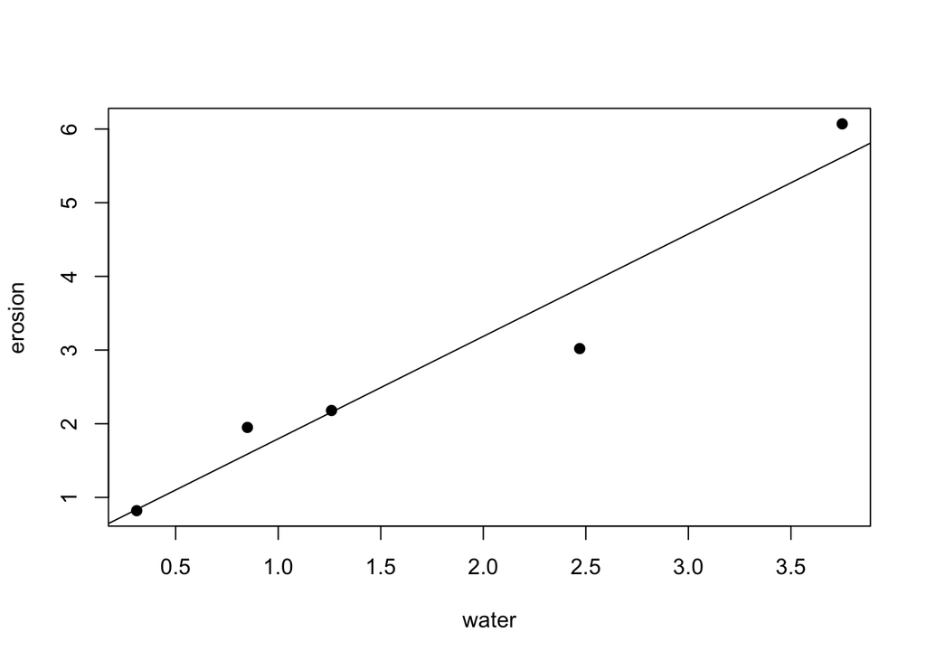

```r
plot(water,erosion,pch=19)
abline(fit)
```

Fitted regression line: $erosion = 0.406 + 1.390 * water$

The least squares estimate for the slope is given by:

$$\hat{\beta}_1 = r\frac{s_y}{s_x}, \\
\text{where sx and sy are the empirical standard deviations of the xis and yis}$$

### Transformations of the outcome / covariates

#### Multiple Linear Regression

Regression model linear in the parameters $\beta_j$, but allows for non-linear effects of the covariates, e.g.:

$$volume = \beta_0 + \beta_1diameter + \beta_2(diameter)^2 + \beta_3height + \epsilon$$

In R, add an I for Inhibit interpretation:

```r
# fit.both=lm(volume~diameter+I(diameter^2)+height, data=trees)
# summary(fit.both)
```

$$log(volume) = \beta_0 + \beta_1log(height) + \beta_2log(diameter) + \epsilon$$

```r
# fit.log=lm(log(volume)~log(height)+log(diameter), data=trees)
# summary(fit.log)
```

### Fitted values and residuals

#### Sums of squares

$$TSS = \sum_{i=1}^n{(y_i-\bar{y})^2} \\
MSS = \sum_{i=1}^n{(\hat{y_i}-\bar{y})^2} \\
RSS = \sum_{i=1}^n{(y_i-\hat{y}_i)^2} \\
TSS \space (total) = MSS \space (model) + RSS \space (residual)$$

#### Residuals

$r_i = y_i - \hat{y}_1$ The residuals are estimates of the unobserved $\epsilon_i's$.

#### Fitted values

##### Multiple linear regression

$\hat{y}_i = \hat{\beta}_0 + \hat{\beta_1x_{1i}} + ... + \hat{\beta_px_{pi}}$

##### Simple linear regression

$\hat{y}_1 = \hat{\beta}_0 + \hat{\beta}_1x_i$